# Initial Data Exploration

## Purpose

This document does a very cursory exploration of the data included for the health care (HC) data files. There are three and each will have its own section.

# HC Chronic

Below is a truncated table to help visualize the raw data that is provided.

| ID | Dataset | Label | Characteristic | Chronic Conditions | 2002 | 2003 | 2004 | 2005 | 2006 |
| --- | --- | --- | --- | --- | --- | --- | --- | --- | --- |
| 1 | Chronic | Age | 18-64 years | 0-1 chronic conditions | 85.1 | 84.9 | 84.5 | 84.0 | 83.7 |
| 2 | Chronic | Age | 18-44 years | 0-1 chronic conditions | 93.3 | 93.2 | 93.0 | 93.0 | 92.9 |
| 3 | Chronic | Age | 18-24 years | 0-1 chronic conditions | 96.4 | 96.7 | 96.8 | 96.6 | 96.2 |
| 4 | Chronic | Age | 25-44 years | 0-1 chronic conditions | 92.3 | 92.0 | 91.7 | 91.7 | 91.8 |
| 5 | Chronic | Age | 45-64 years | 0-1 chronic conditions | 71.4 | 71.6 | 70.9 | 70.2 | 69.9 |
| 6 | Chronic | Age | 45-54 years | 0-1 chronic conditions | 78.4 | 79.1 | 77.6 | 77.8 | 77.1 |

The columns included are:

- ID
- Dataset
- Label
- Characteristic
- Chronic Conditions
- 2002
- 2003
- 2004
- 2005
- 2006
- 2007
- 2008
- 2009
- 2010
- 2011
- 2012

The columns with year indicators likely have the calculation ‘*characteristic multiplier factors*’ which is the value we will eventually be forecasting. The ID column is a unique identifier for each row and won’t really be of use during the analysis. Data set is an indicator for which data set it comes from Chronic, Insurance, or Vaccinations. This will only become useful should the analysis require all three data sets to be appended. This leaves Label, Characteristic, and Chronic Condidtions as the dimensions that will drive the analytic.

To that end, each of these dimension contains the following values:

| Label |
| --- |
| Age |
| Sex |
| Pct Poverty |
| InsStatus |
| Geo |

| Characteristic |
| --- |
| 18-64 years |
| 18-44 years |
| 18-24 years |
| 25-44 years |
| 45-64 years |
| 45-54 years |
| 55-64 years |
| 65 years and over |
| 65-74 years |
| 75 years and over |
| Male |
| Female |
| Below 100% |
| 100%-199% |
| 200%-399% |
| 400% or more |
| Insured |
| Private |
| Medicaid |
| Uninsured |
| Northeast |
| Midwest |
| South |
| West |

| Chronic Conditions |
| --- |
| 0-1 chronic conditions |
| 2-3 chronic conditions |
| 4 or more chronic conditions |

The case study says of the chronic data:

For chronic illness, provide the top three label/characteristics for each group: 1 chronic illness, 2–3 chronic illness, and 4+ chronic illness. For the identified top three, generate a multiplier and coefficient by forecasting the next value using 2002 through 2012.

This means to me, we’ll need to decide on how to quantify and rank these groups using the yearly multiplier and coefficient. Some initial ways that this might be done are to just sum the coefficients for the entire time frame, use an average, use a mean, use a median, or even use a weighted mean.

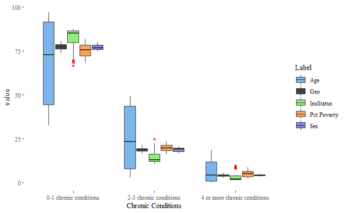

| Label | Characteristic | Chronic Conditions | summed | avg | med | n.val |
| --- | --- | --- | --- | --- | --- | --- |
| Age | 18-24 years | 0-1 chronic conditions | 1063.5 | 96.6818182 | 96.6 | 11 |
| Age | 18-44 years | 0-1 chronic conditions | 1021.6 | 92.8727273 | 93.0 | 11 |
| Age | 18-64 years | 0-1 chronic conditions | 916.1 | 83.2818182 | 83.7 | 11 |
| Age | 25-44 years | 0-1 chronic conditions | 1006.8 | 91.5272727 | 91.7 | 11 |
| Age | 45-54 years | 0-1 chronic conditions | 843.4 | 76.6727273 | 77.1 | 11 |
| Age | 45-64 years | 0-1 chronic conditions | 761.1 | 69.1909091 | 69.9 | 11 |
| Age | 55-64 years | 0-1 chronic conditions | 652.3 | 59.3000000 | 59.6 | 11 |
| Age | 65-74 years | 0-1 chronic conditions | 482.9 | 43.9000000 | 43.8 | 11 |
| Age | 65 years and over | 0-1 chronic conditions | 444.6 | 40.4181818 | 40.7 | 11 |
| Age | 75 years and over | 0-1 chronic conditions | 399.8 | 36.3454545 | 36.6 | 11 |
| Geo | Midwest | 0-1 chronic conditions | 839.3 | 76.3000000 | 76.1 | 11 |
| Geo | Northeast | 0-1 chronic conditions | 864.1 | 78.5545455 | 78.6 | 11 |
| Geo | South | 0-1 chronic conditions | 831.1 | 75.5545455 | 76.1 | 11 |
| Geo | West | 0-1 chronic conditions | 868.5 | 78.9545455 | 79.0 | 11 |
| InsStatus | Insured | 0-1 chronic conditions | 925.5 | 84.1363636 | 84.4 | 11 |
| InsStatus | Medicaid | 0-1 chronic conditions | 765.0 | 69.5454545 | 69.6 | 11 |
| InsStatus | Private | 0-1 chronic conditions | 950.6 | 86.4181818 | 86.5 | 11 |
| InsStatus | Uninsured | 0-1 chronic conditions | 952.4 | 86.5818182 | 86.7 | 11 |
| Pct Poverty | 100%-199% | 0-1 chronic conditions | 813.3 | 73.9363636 | 74.4 | 11 |
| Pct Poverty | 200%-399% | 0-1 chronic conditions | 846.4 | 76.9454545 | 77.0 | 11 |
| Pct Poverty | 400% or more | 0-1 chronic conditions | 880.8 | 80.0727273 | 80.1 | 11 |
| Pct Poverty | Below 100% | 0-1 chronic conditions | 771.6 | 70.1454545 | 69.5 | 11 |
| Sex | Female | 0-1 chronic conditions | 835.2 | 75.9272727 | 76.0 | 11 |
| Sex | Male | 0-1 chronic conditions | 859.9 | 78.1727273 | 78.4 | 11 |
| Age | 18-24 years | 2-3 chronic conditions | 35.1 | 3.1909091 | 3.2 | 11 |
| Age | 18-44 years | 2-3 chronic conditions | 72.5 | 6.5909091 | 6.5 | 11 |
| Age | 18-64 years | 2-3 chronic conditions | 157.5 | 14.3181818 | 13.9 | 11 |
| Age | 25-44 years | 2-3 chronic conditions | 85.5 | 7.7727273 | 7.7 | 11 |
| Age | 45-54 years | 2-3 chronic conditions | 220.9 | 20.0818182 | 19.8 | 11 |
| Age | 45-64 years | 2-3 chronic conditions | 282.4 | 25.6727273 | 25.2 | 11 |
| Age | 55-64 years | 2-3 chronic conditions | 364.5 | 33.1363636 | 33.1 | 11 |
| Age | 65-74 years | 2-3 chronic conditions | 481.2 | 43.7454545 | 43.7 | 11 |
| Age | 65 years and over | 2-3 chronic conditions | 502.6 | 45.6909091 | 46.0 | 11 |
| Age | 75 years and over | 2-3 chronic conditions | 527.2 | 47.9272727 | 48.0 | 11 |
| Geo | Midwest | 2-3 chronic conditions | 211.9 | 19.2636364 | 19.3 | 11 |
| Geo | Northeast | 2-3 chronic conditions | 197.3 | 17.9363636 | 18.0 | 11 |
| Geo | South | 2-3 chronic conditions | 217.6 | 19.7818182 | 19.5 | 11 |
| Geo | West | 2-3 chronic conditions | 192.3 | 17.4818182 | 17.4 | 11 |
| InsStatus | Insured | 2-3 chronic conditions | 150.2 | 13.6545455 | 13.5 | 11 |
| InsStatus | Medicaid | 2-3 chronic conditions | 241.6 | 21.9636364 | 21.7 | 11 |
| InsStatus | Private | 2-3 chronic conditions | 134.9 | 12.2636364 | 12.0 | 11 |
| InsStatus | Uninsured | 2-3 chronic conditions | 128.3 | 11.6636364 | 11.7 | 11 |
| Pct Poverty | 100%-199% | 2-3 chronic conditions | 222.4 | 20.2181818 | 20.2 | 11 |
| Pct Poverty | 200%-399% | 2-3 chronic conditions | 210.5 | 19.1363636 | 19.0 | 11 |
| Pct Poverty | 400% or more | 2-3 chronic conditions | 188.1 | 17.1000000 | 17.0 | 11 |
| Pct Poverty | Below 100% | 2-3 chronic conditions | 244.1 | 22.1909091 | 22.3 | 11 |
| Sex | Female | 2-3 chronic conditions | 217.1 | 19.7363636 | 19.6 | 11 |
| Sex | Male | 2-3 chronic conditions | 195.9 | 17.8090909 | 17.6 | 11 |
| Age | 18-24 years | 4 or more chronic conditions | 0.0 | 0.0000000 | 0.0 | 11 |
| Age | 18-44 years | 4 or more chronic conditions | 6.0 | 0.5454545 | 0.5 | 11 |
| Age | 18-64 years | 4 or more chronic conditions | 26.5 | 2.4090909 | 2.4 | 11 |
| Age | 25-44 years | 4 or more chronic conditions | 7.7 | 0.7000000 | 0.7 | 11 |
| Age | 45-54 years | 4 or more chronic conditions | 35.9 | 3.2636364 | 3.2 | 11 |
| Age | 45-64 years | 4 or more chronic conditions | 56.3 | 5.1181818 | 5.3 | 11 |
| Age | 55-64 years | 4 or more chronic conditions | 83.2 | 7.5636364 | 7.9 | 11 |
| Age | 65-74 years | 4 or more chronic conditions | 135.9 | 12.3545455 | 12.0 | 11 |
| Age | 65 years and over | 4 or more chronic conditions | 152.8 | 13.8909091 | 13.3 | 11 |
| Age | 75 years and over | 4 or more chronic conditions | 172.8 | 15.7090909 | 15.7 | 11 |
| Geo | Midwest | 4 or more chronic conditions | 49.0 | 4.4545455 | 4.5 | 11 |
| Geo | Northeast | 4 or more chronic conditions | 38.4 | 3.4909091 | 3.5 | 11 |
| Geo | South | 4 or more chronic conditions | 51.3 | 4.6636364 | 4.4 | 11 |
| Geo | West | 4 or more chronic conditions | 39.0 | 3.5454545 | 3.4 | 11 |
| InsStatus | Insured | 4 or more chronic conditions | 24.2 | 2.2000000 | 2.2 | 11 |
| InsStatus | Medicaid | 4 or more chronic conditions | 93.5 | 8.5000000 | 8.4 | 11 |
| InsStatus | Private | 4 or more chronic conditions | 14.6 | 1.3272727 | 1.3 | 11 |
| InsStatus | Uninsured | 4 or more chronic conditions | 19.3 | 1.7545455 | 1.7 | 11 |
| Pct Poverty | 100%-199% | 4 or more chronic conditions | 64.0 | 5.8181818 | 6.1 | 11 |
| Pct Poverty | 200%-399% | 4 or more chronic conditions | 43.1 | 3.9181818 | 3.8 | 11 |
| Pct Poverty | 400% or more | 4 or more chronic conditions | 31.2 | 2.8363636 | 2.8 | 11 |
| Pct Poverty | Below 100% | 4 or more chronic conditions | 84.4 | 7.6727273 | 8.1 | 11 |
| Sex | Female | 4 or more chronic conditions | 47.5 | 4.3181818 | 4.3 | 11 |
| Sex | Male | 4 or more chronic conditions | 44.5 | 4.0454545 | 4.1 | 11 |